# Psychology 2830A

# **So Many Inferential Tests (Or Are There?)**

### **The General Linear Model**

Welp, we’ve made it to the end of the semester. Congratulations! We have covered many types of inferential statistics tests (and when to use them), including *t*-tests, ANOVAs, Pearson correlations, and linear regressions.

Remembering the specifics of each of these tests might feel daunting, so I am now going to tell you something that will very likely confuse, then infuriate, then intrigue you: **these tests are actually not *that* different from one another**. In fact, all of the parametric tests we have covered this semester are variants of the *general linear model*.

“What is the general linear model,” you might ask? Very good question! The general linear model is *a statistical framework that describes the relationship between one or more dependent variables (outcomes) and independent variables (predictors) by modeling the outcome as a linear combination of predictors plus an error term*. The formula for the general linear model can be expressed in the following way:

$Y = \beta_0 + \beta_1X_1 + \beta_2X_2 + ... + \beta_pX_p + \epsilon$

If you’ve been paying attention in class, you might be thinking that this formula looks familiar. That’s because it is quite similar to the linear regression formula! In class, we had shown the following formula to introduce linear regression:

$\hat{Y} = A + BX$

In class, we dropped epsilon ($\epsilon$) from the equation for simplicity’s sake, although this represents the random error (i.e., all the variance that is not accounted for by the fixed terms in the model), and we added a fancy hat to Y to indicate that this was a predicted value of Y, and we only considered a single independent (predictor) variable (X). But, other than those small differences, we see that both the linear regression and general linear model equations involve an intercept and slopes associated with different variables in the model.

### So where do all of these inferential tests fit in?

Basically, we can think of the general linear model as the “parent” or “umbrella” model, which encompasses more specific types of tests (*t*-tests, ANOVAs, correlations). The reason it is so flexible is because (1) researchers can add as many terms (predictors) as they wish, and (2) these predictors can be categorical (e.g., statistics-lover versus statistics-hater) or continuous (e.g., final grade earned in this course).

Put another way, we can think of the specific inferential tests we covered as *specialized cases of the general linear model*. For the independent samples *t*-test, for example, we had a continuous dependent variable and a single categorical variable with two levels. For the one-way ANOVA, we had a continuous dependent variable and a single categorical variable with three or more levels. For the factorial ANOVA, we had a continuous dependent variable and at least two categorical variables, each with at least two levels. In this sense, we can think of these tests as differing in their flexibility. A *t*-test is the least flexible test, as we are kind of out of luck once we have more than two levels of a categorical variable. A one-way ANOVA is slightly more flexible, as it can deal with a categorical variable having more than two levels. A factorial ANOVA is even more flexible, as it can deal with multiple categorical variables, each with differing numbers of levels.

What this means is that if we have a dataset that is amenable to a *t*-test (e.g., single, continuous dependent variable and a single categorical variable with two levels), we actually can use *any* of the more flexible variants of the general linear model, and we’ll end up with the same conclusions! Obviously the test statistic itself will change (e.g., from *t* to *F*), but the effect size and the underlying *p*-value will be consistent. We will now illustrate this using an actual dataset.

[figure not shown]

SVH’s first meme.

### **Illustrating the Connections between T-Tests, ANOVAs, Correlations, and Regressions**

### The Dataset

Rather than making up some data (which was useful for our sampling distribution pages), we will use an *actual* dataset to illustrate the connections between different inferential tests. Specifically, we’ll use some data from one of my former student’s papers (Babalola et al., 2024), examining differences among individuals with and without *misophonia*. Misophonia is commonly defined as an extreme, negative emotional reaction to particular sounds, such as chewing, tapping, breathing, or lip smacking. In this work, participants (*n* = 300) initially completed a misophonia screening questionnaire, and then a subset of participants matched on demographic variables (e.g., age, gender, race) who were either high (*n* = 40) or low (*n* = 58) in misophonia severity completed a follow-up study. In this follow-up study, we found several differences between the participants in the high versus low misophonia groups, including a stronger emotional response to music for individuals who were higher in misophonia. We’ll focus on this “emotion evocation” measure as our dependent variable, and the categorization of participants in the high versus low misophonia groups is our single categorical variable with two levels.

In case you are interested in learning more about the work, I encourage you to check out the paper:

**Babalola, O., Van Hedger, K., & Van Hedger, S.C. (2024). Misophonia is associated with heightened emotion evocation by music. *Current Psychology*, *43*, 36294-36305. https://doi.org/10.1007/s12144-024-07050-w**

### Independent Samples T-Test

First, let’s load the relevant dataset. If you wish to follow along, you can access the data on this GitHub page or on Open Science Framework.

```r
data <- read.csv("data/misophonia.csv")
```

There are many measured outcome variables in this dataset, so let’s select the relevant variables for this exercise. Specifically, what we need is the variable that denotes whether one is in the high versus low misophonia group (*Misophonia*), and the emotion evocation variable from the Barcelona Musical Reward Questionnaire (*BMRQ.EVOCATION.OVERALL*).

```r
data.emo <- data[, c("Misophonia", "BMRQ.EVOCATION.OVERALL")]
```

Now we can run our independent samples *t*-test on the data. The formula for the independent samples *t*-test we introduced in class is:

$t = \frac{\bar{X}_1 - \bar{X}_2}{s_p\sqrt{\frac{1}{n_1}+\frac{1}{n_2}}}$

where $s_p$ is the pooled variance. This formula (which represents the Student’s *t*-test) assumes that the variance between the two groups is equal. If this assumption is violated, we can use the following formula (which represents the Welch’s *t*-test), with an adjustment to the degrees of freedom:

$t = \frac{\bar{X}_1 - \bar{X}_2}{\sqrt{\frac{s^2_1}{n_1}+\frac{s^2_2}{n_2}}}$

We can assess whether the variances between the high and low misophonia groups are equal using a Levene’s Test for the equality of variances. In the current scenario, the Levene’s test is nonsignificant, so we would be licensed to use the Student’s *t*-test. That being said, we’ll run both a Student’s *t*-test and a Welch’s *t*-test to compare the output.

```r
#Check for equal variances of groups
leveneTest(data.emo$BMRQ.EVOCATION.OVERALL ~ data.emo$Misophonia)
```

```
## Levene's Test for Homogeneity of Variance (center = median)
##       Df F value Pr(>F)
## group  1  1.5389 0.2178
##       96
```

```r
#Student's T-Test
t.test(data.emo$BMRQ.EVOCATION.OVERALL ~ data.emo$Misophonia, var.equal=T)
```

```
##
##  Two Sample t-test
##
## data:  data.emo$BMRQ.EVOCATION.OVERALL by data.emo$Misophonia
## t = 2.635, df = 96, p-value = 0.00981
## alternative hypothesis: true difference in means between group h and group l is not equal to 0
## 95 percent confidence interval:
##  0.1164530 0.8276561
## sample estimates:
## mean in group h mean in group l
##        3.956250        3.484195
```

```r
#Welch's T-Test
t.test(data.emo$BMRQ.EVOCATION.OVERALL ~ data.emo$Misophonia, var.equal=F)
```

```
##
##  Welch Two Sample t-test
##
## data:  data.emo$BMRQ.EVOCATION.OVERALL by data.emo$Misophonia
## t = 2.7172, df = 91.942, p-value = 0.007868
## alternative hypothesis: true difference in means between group h and group l is not equal to 0
## 95 percent confidence interval:
##  0.1270081 0.8171011
## sample estimates:
## mean in group h mean in group l
##        3.956250        3.484195
```

What do we see? First off, the Levene’s test is nonsignificant (*p* = .218), so as mentioned previously we would be licensed to use the Student’s *t*-test. However, regardless of what *t*-test we end up using, we see very similar results: Individuals who scored higher on the misophonia screening measure also had significantly higher emotion evocation scores (*M* = 3.96) compared to individuals who scored lower on the misophonia screening measure (*M* = 3.48). The *t*-value for the Student’s *t*-test is 2.635 (df = 96), and the *p*-value is .00981.

So, now what? Now comes the “fun” stuff - **let’s analyze the same dataset using an ANOVA, a Pearson’s correlation, and a linear regression**. As noted earlier, although the specific test statistics will of course change, the underlying *p*-values and effect sizes will be identical.

On that last point, let’s calculate an effect size for the *t*-test we just ran. Although Cohen’s *d* is probably the most common measure of effect size for a *t*-test, here we will calculate eta-squared ($\eta^2$), which represents the proportion of variance in the dependent variable that is explained by the outcome (grouping) variable. The formula for calculating eta-squared for a *t*-test, as noted in class, is:

$\eta^2 = \frac{t^2}{t^2 + df}$

where *t* represents the observed *t*-statistic, and *df* represents the degrees of freedom. Thus, if we are using the Student’s *t*-test values, we would have the following eta-squared:

$\eta^2 = \frac{2.635^2}{2.635^2 + 96} = \frac{6.943}{102.943} = .067$

meaning that 6.7% (pronounced “six point seeeeeeven percent”) of the variance in the emotion evocation scores can be explained by misophonia group. Neat! Okay, now, for real, let’s continue our journey. Next stop: ANOVA land!

### Analyses of Variance (ANOVAs)

ANOVAs were introduced in class as a more flexible statistical test compared to *t*-tests, as one can assess differences among more than two groups. Although a one-way ANOVA is typically used when one has three or more groups, there is nothing stopping us from using a one-factor ANOVA to analyze the current dataset, which only has a single factor with two levels.

Recall that in an ANOVA, we care about partitioning sources of variance in the data. The **total** variance in the data can be represented by considering each individual score as it compares to the *grand mean* (i.e., the overall mean, ignoring the grouping variables). We typically represent variance in terms of the *sum of squares*. For the total sum of squares ($SS_{Total}$), the formula is thus:

$SS_{Total} = \sum\limits_{i=0}^n({X} - \bar{X_G})^2$

This total sum of squares is comprised of both the sum of squares for our grouping factor ($SS_A$) and the sum of squares of our error term ($SS_{Error}$).The formulas for each are provided below:

$SS_{A} = \sum\limits_{i=0}^n({\bar{X_A}} - \bar{X_G})^2$  
$SS_{Error} = \sum\limits_{i=0}^n({X} - \bar{X_A})^2$

Finally, recall that once we have partitioned the variance in this manner ($SS_{Total} = SS_{A} + SS_{Error}$), we then divide by the relevant degrees of freedom to calculate the *mean squared* values ($MS_{A}$, $MS_{Error}$). For $MS_{A}$, we divide $SS_{A}$ by the numerator degrees of freedom ($a - 1$, where a = the number of levels of Factor A). For $MS_{Error}$, we divide $SS_{Error}$ by the denominator degrees of freedom ($N - a$, where N = the total sample size and a = the number of levels of Factor A). Once we have $MS_{A}$ and $MS_{Error}$, calculating the *F*-statistic is quite easy:

$F = \frac{MS_A}{MS_{Error}}$

Enough talk - let’s run a one-factor ANOVA on our misophonia dataset and see what happens!

```r
summary(aov(BMRQ.EVOCATION.OVERALL ~ Misophonia, data=data.emo))
```

```
##             Df Sum Sq Mean Sq F value  Pr(>F)
## Misophonia   1   5.28   5.275   6.943 0.00981 **
## Residuals   96  72.94   0.760
## ---
## Signif. codes:  0 '***' 0.001 '**' 0.01 '*' 0.05 '.' 0.1 ' ' 1
```

Perhaps the first thing that pops out of this analysis is the *p*-value. **It is identical to the Student’s *t*-test *p*-value we just calculated!**. Despite taking a seemingly different approach to assessing statistical significance, we see that a one-factor ANOVA and an independent samples *t*-test yield identical results. The main difference, then, is that the one-factor ANOVA is a more flexible test (as it can be used when there are more than two groups).

Let’s provide even more evidence in support of this point that *t*-tests and ANOVAs really are the same thing at their core. One way of doing this is to calculate an effect size for our *F*-statistic. For consistency’s sake, we’ll continue to use eta-squared ($\eta^2$), which can be calculated from a one-factor ANOVA in the following manner:

$\eta^2 = \frac{SS_A}{SS_{Total}} = \frac{5.28}{5.28 + 72.94} = \frac{5.28}{78.22} = .067$

*It’s the same as what we calculated from the independent samples t-test!* If that doesn’t seal it for you, consider this: when using an ANOVA to analyze two groups, **the *F*-statistic is equal to the squared *t*-statistic**! Yes, you read that right. Let’s demonstrate this using our misophonia dataset:

$F = t^2$  
$F = 2.635^2$  
$F = 6.943$

You can end up going down a bit of a rabbit hole to actually reduce the formulas to prove that $F = t^2$ in the instance where there are exactly two groups, but we’ll leave that be for now. Onto the next inferential test - Pearson correlation!

### Pearson Correlation

We had introduced the Pearson correlation coefficient as a means of assessing the *linear* relationship between two continuous variables. In this way, correlations broke free of the constraints of both *t*-tests and ANOVAs, which required one variable to be continuous (the dependent variable) and the rest of the variables to be categorical (such as the “high” versus “low” misophonia groups in our present example).

“HOLD THE PHONE,” you might say at this point (but realistically you probably wouldn’t say this because you are not super old like I am). “WE CANNOT USE CORRELATION HERE - MISOPHONIA SEVERITY IS A CATEGORICAL VARIABLE!” If you were to say something like this, you would be correct on one account. Misophonia severity *is* categorical, but that does not mean we cannot use correlation. However, before using a correlation, we need to represent misophonia severity as a **dummy variable**.

#### What is a dummy variables?

A dummy variable is a numerical representation of a categorical variable, indicating the presence or absence of that category. For example, we could create a dummy variable called *high misophonia*, which would have a value of 1 for the 40 individuals who were in the high misophonia group and a value of 0 for the 58 participants in the low misophonia group. Alternatively, we could create a dummy variable called *low misophonia*, which would have a value of 0 for the 40 individuals who were in the high misophonia group and a value of 1 for the 58 participants in the low misophonia group. One only needs to create $a-1$ dummy variables (where *a* represents the number of levels of a categorical variable). So, in the present situation, we would only need to create a *high misophonia* **or** a *low misophonia* dummy variable. However, for illustrative purposes, we’ll go ahead and create both variables. Let’s do this right now - then we’ll get back to correlations.

```r
data.emo$Misophonia.High <- ifelse(data.emo$Misophonia == "h", 1, 0)
data.emo$Misophonia.Low <- ifelse(data.emo$Misophonia == "l", 1, 0)

#Check to confirm that dummy coding was done correctly
head(data.emo)
```

```
##   Misophonia BMRQ.EVOCATION.OVERALL Misophonia.High Misophonia.Low
## 1          h               4.000000               1              0
## 2          l               3.333333               0              1
## 3          h               4.500000               1              0
## 4          l               5.000000               0              1
## 5          l               1.500000               0              1
## 6          h               2.250000               1              0
```

Pretty simple to do - we just used the built-in *ifelse* function in R to examine whether the Misophonia variable contained an “h” or “l” for *high* or *low* respectively, and then created some new variables (Misophonia.High and Misophonia.Low) that dummy coded these category levels into 1s and 0s. We can confirm that this worked correctly by verifying that between the two new variables (Misophonia.High and Misophonia.Low), there is always one 1 and one 0 for each row. There cannot be two 1s in the same row (i.e., someone cannot belong to *both* the high and low misophonia groups), and similarly there cannot be two 0s in the same row (i.e., someone must belong to one of the groups).

Now that we have created some dummy variables, we can turn back to correlations. There are different formulas for calculating Pearson correlation coefficients, but each lead to the same coefficient. In class, we introduced the standard scores formula:

$r = \frac{\Sigma(Z_xZ_y)}{n-1}$

where $Z_x$ and $Z_y$ represent the *z*-transformed scores, which we could get for each variable by using the following formula:

$Z_x = \frac{X - \bar{X}}{SD_X}$  
$Z_y = \frac{Y - \bar{Y}}{SD_Y}$

Now that we have numeric dummy variables, we can use this formula and calculate a Pearson correlation coefficient. Before creating the dummy variables, we’d be out of luck (e.g., what is the mean of 40 “h” and 58 “l” values? It’s nonsensical). However, now, we can calculate that the mean for Misophonia.High is .408 (*SD* = .494) and the mean for Misophonia.Low is .592 (*SD* = .494). Note that due to the nature of dummy variables, these means tell us the proportion of participants that fall into these respective categories (i.e., 40.8% participants were in the high misophonia group and 59.2% of participants were in the low misophonia group).

Alternatively, we could just use the built-in functions of “cor” or “cor.test” in R if you want to avoid all of that hand calculation stuff. :)

```r
cor.test(data.emo$BMRQ.EVOCATION.OVERALL, data.emo$Misophonia.High)
```

```
##
##  Pearson's product-moment correlation
##
## data:  data.emo$BMRQ.EVOCATION.OVERALL and data.emo$Misophonia.High
## t = 2.635, df = 96, p-value = 0.00981
## alternative hypothesis: true correlation is not equal to 0
## 95 percent confidence interval:
##  0.06461775 0.43567824
## sample estimates:
##       cor
## 0.2597087
```

```r
cor.test(data.emo$BMRQ.EVOCATION.OVERALL, data.emo$Misophonia.Low)
```

```
##
##  Pearson's product-moment correlation
##
## data:  data.emo$BMRQ.EVOCATION.OVERALL and data.emo$Misophonia.Low
## t = -2.635, df = 96, p-value = 0.00981
## alternative hypothesis: true correlation is not equal to 0
## 95 percent confidence interval:
##  -0.43567824 -0.06461775
## sample estimates:
##        cor
## -0.2597087
```

Getting pretty freaky, eh? Once again, *we are staring at the exact same p-value* (*p* = .00981). What’s more, it does not matter whether we correlate emotion evocation with the “Misophonia.High” or “Misophonia.Low” dummy variables - the results are identical (the only thing that changes is whether the Pearson correlation coefficient is positive or negative). To be clear, the Pearson correlation coefficient is the final thing printed in the output (so, it is either *r* = .2597 or *r* = -.2597 depending on which dummy variable one uses).

You might also be surprised to see an associated *t*-value with the “cor.test” function. Aren’t we talking about *r*-values, not *t*-values? Yes and no. Remember that **everything is connected**. In the present context, Pearson correlation coefficients (*r*-statistics) relate to *t*-statistics in the following way:

$t = \frac{r\sqrt{n-2}}{\sqrt{1 - r^2}}$

So, with our calculated *r*-statistic of .2597, we can see that this does indeed correspond to the Student’s *t*-statistic we calculated earlier (2.635):

$t = \frac{.2597\sqrt{98-2}}{\sqrt{1 - .2597^2}} = \frac{.2597\sqrt{96}}{\sqrt{1 - .06744}} = \frac{2.545}{\sqrt{.9326}} = \frac{2.545}{0.9657} = 2.635$

If you’re playing along at home, you might be off by a couple of one-thousandths depending on intermediary rounding, but hopefully you get the point, which is that *any Pearson correlation coefficient can be represented as a t-statistic* (and vice versa).

In class, we had mentioned that, unlike *t*- or *F*-statistics, Pearson correlation coefficient were **both** test statistics *and* measures of effect size. We had also specifically introduced the coefficient of determination ($R^2$), which represents the proportion of shared variance between two variables. Anyone want to venture a guess as to what the $R^2$ value will be for the present example?

$R^2 = .2597^2 = .067$

**It’s the same as the eta-squared values from the *t*-test and ANOVA!** Upon further reflection, this shouldn’t be all that surprising, as eta-squared represented the proportion of variance in the dependent variable explained by the grouping variable.

Let’s conclude our tour of the general linear model by analyzing the data using the most flexible approach we have covered this term - linear regression.

### Linear Regression

Linear regression is a statistical approach that allows us to model the relationship between a dependent variable (sometimes called the *outcome variable*) and one or more independent variables (sometimes called *predictor variables*), specifically by fitting the best straight line through the data. Although the dependent variable still needs to be continuous and normally distributed (as these are assumptions that all inferential tests under the general linear model make), the independent variable(s) can take on any form. They can be categorical (in which case, they are treated as dummy variables), and additionally, the same linear regression model can include both categorical and continuous variables, to see how each contribute to the line of best fit in predicting the dependent variable. One can even include interaction terms (e.g., assessing how the linear relationship between two variables changes as a function of changes in a third variable), and these interaction terms can include both continuous and categorical variables, making linear regression even more flexible than the factorial ANOVAs we discussed in class (in which the factors need to be categorical).

The simple linear regression formula we introduced in class ($\hat{Y} = A + BX$) is sufficient for our current example dataset, as we only have one independent variable (Misophonia). Let’s create the linear regression model and view the results. Before continuing, take a moment to make some predictions. What do you think the associated *p*-value will be for the Misophonia term? If that term has an associated *t*-value, what do you think it will be? What do you think the model’s effect size (measured via $R^2$ will be?)

```r
summary(lm(BMRQ.EVOCATION.OVERALL ~ Misophonia.High, data=data.emo))
```

```
##
## Call:
## lm(formula = BMRQ.EVOCATION.OVERALL ~ Misophonia.High, data = data.emo)
##
## Residuals:
##     Min      1Q  Median      3Q     Max
## -1.9842 -0.4842  0.1548  0.5437  1.5158
##
## Coefficients:
##                 Estimate Std. Error t value Pr(>|t|)
## (Intercept)       3.4842     0.1145  30.442  < 2e-16 ***
## Misophonia.High   0.4721     0.1791   2.635  0.00981 **
## ---
## Signif. codes:  0 '***' 0.001 '**' 0.01 '*' 0.05 '.' 0.1 ' ' 1
##
## Residual standard error: 0.8716 on 96 degrees of freedom
## Multiple R-squared:  0.06745,    Adjusted R-squared:  0.05773
## F-statistic: 6.943 on 1 and 96 DF,  p-value: 0.00981
```

**Wow.** There are a lot of familiar-looking numbers in this output, aren’t there? Seems to be about the right time to place an “everything is connected” sort of meme in here.

[figure not shown]

Let’s take a closer look at some of these familiar-looking numbers. For ease of review, I’ll paste a screenshot from the output as this preserves the formatting and allows me to highlight some relevant values.

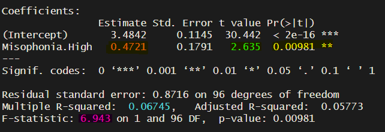

First, we can see that the *p*-value associated with the Misophonia variable (highlighted in yellow) is identical to the *p*-values from the *t*-test, ANOVA, and Pearson correlation we ran previously. Second, we can see that the *t*-value associated with this term (highlighted in green) is identical to the *t*-values we calculated earlier. Third, we can see that the model’s overall *F*-statistic (highlighted in pink) is identical to the *F*-statistic we calculated from the ANOVA. Fourth, we can see that the effect size of the model ($R^2$, highlighted in blue) is .067 - identical to the eta-squared effect sizes from the *t*-test and ANOVA, and identical to the $R^2$ calculated from the Pearson correlation coefficient. Fifth, we can extract the slope (beta) of the misophonia term by looking at the “Estimate” column in the output (highlighted in orange). Here, we see that the slope is 0.4721. Although this might *seem* like a new number (finally!), I am sorry to report that it is not. First, let’s think about what the slope represents. The slope represents how much emotion evocation changes as we increase one unit of the independent (predictor) variable. Because the independent variable is categorical and had to be treated as a dummy variable, the “one unit” of change here represents going from the low misophonia group to the high misophonia group. So, the slope is simply the mean difference in emotion evocation scores between these two groups, which was printed as a part of the *t*-test output way back when:

$M = 3.956$ (High Misophonia Group)  
$M = 3.484$ (Low Misophonia Group)  
$3.956 - 3.484 = 0.472$

At this point, you might be wondering what happens if we re-run the regression model using the “Misophonia.Low” variable as the independent variable. Let’s find out:

```r
summary(lm(BMRQ.EVOCATION.OVERALL ~ Misophonia.Low, data=data.emo))
```

```
##
## Call:
## lm(formula = BMRQ.EVOCATION.OVERALL ~ Misophonia.Low, data = data.emo)
##
## Residuals:
##     Min      1Q  Median      3Q     Max
## -1.9842 -0.4842  0.1548  0.5437  1.5158
##
## Coefficients:
##                Estimate Std. Error t value Pr(>|t|)
## (Intercept)      3.9562     0.1378  28.706  < 2e-16 ***
## Misophonia.Low  -0.4721     0.1791  -2.635  0.00981 **
## ---
## Signif. codes:  0 '***' 0.001 '**' 0.01 '*' 0.05 '.' 0.1 ' ' 1
##
## Residual standard error: 0.8716 on 96 degrees of freedom
## Multiple R-squared:  0.06745,    Adjusted R-squared:  0.05773
## F-statistic: 6.943 on 1 and 96 DF,  p-value: 0.00981
```

Hmmm, what if we don’t use our dummy coded variables, but instead use the original Misophonia variable (with “h” and “l” values, instead of 1s and 0s)?

```r
summary(lm(BMRQ.EVOCATION.OVERALL ~ Misophonia, data=data.emo))
```

```
##
## Call:
## lm(formula = BMRQ.EVOCATION.OVERALL ~ Misophonia, data = data.emo)
##
## Residuals:
##     Min      1Q  Median      3Q     Max
## -1.9842 -0.4842  0.1548  0.5437  1.5158
##
## Coefficients:
##             Estimate Std. Error t value Pr(>|t|)
## (Intercept)   3.9562     0.1378  28.706  < 2e-16 ***
## Misophonial  -0.4721     0.1791  -2.635  0.00981 **
## ---
## Signif. codes:  0 '***' 0.001 '**' 0.01 '*' 0.05 '.' 0.1 ' ' 1
##
## Residual standard error: 0.8716 on 96 degrees of freedom
## Multiple R-squared:  0.06745,    Adjusted R-squared:  0.05773
## F-statistic: 6.943 on 1 and 96 DF,  p-value: 0.00981
```

Interestingly, it did not break the model! Rather, R automatically created dummy variables, treating the first level alphabetically (“h”) as 0 and the second level (“l”) as 1. Thus, the output is identical to the last regression we ran - although, if you look carefully at the *name* of the term in the output, you might think that R is having the computer equivalent of a stroke. It says “Misophonial” which is not the name of the variable. What gives? Well, R has added the “l” at the end of the original variable name (“Misophonia”) to indicate that, relative to the reference level (here, “h”), the “l” level decreases emotion evocation scores by 0.472. If we were to relevel the factors (treating “l” as the reference level), R would automatically name this variable “Misophoniah.”

Okay, that was perhaps too detailed of a point, especially if you have no plans on using R for your research. Let’s explore one more, quite important concept - *what happens if we put both dummy variables in the same model*??

```r
summary(lm(BMRQ.EVOCATION.OVERALL ~ Misophonia.High + Misophonia.Low, data=data.emo))
```

```
##
## Call:
## lm(formula = BMRQ.EVOCATION.OVERALL ~ Misophonia.High + Misophonia.Low,
##     data = data.emo)
##
## Residuals:
##     Min      1Q  Median      3Q     Max
## -1.9842 -0.4842  0.1548  0.5437  1.5158
##
## Coefficients: (1 not defined because of singularities)
##                 Estimate Std. Error t value Pr(>|t|)
## (Intercept)       3.4842     0.1145  30.442  < 2e-16 ***
## Misophonia.High   0.4721     0.1791   2.635  0.00981 **
## Misophonia.Low        NA         NA      NA       NA
## ---
## Signif. codes:  0 '***' 0.001 '**' 0.01 '*' 0.05 '.' 0.1 ' ' 1
##
## Residual standard error: 0.8716 on 96 degrees of freedom
## Multiple R-squared:  0.06745,    Adjusted R-squared:  0.05773
## F-statistic: 6.943 on 1 and 96 DF,  p-value: 0.00981
```

We see **mostly** the same output, but there are no values associated with one of the dummy variables. This makes sense - remember, all we need is ($a - 1$) dummy variables (where *a* represents the levels of a categorical variable). By including both dummy variables, we are not adding any new information. By definition, if a row has a value of 1 for “Misophonia.High” then it will have a 0 for “Misophonia.Low” (and vice versa), meaning these two variables are *perfectly negatively correlated*:

```r
cor(data.emo$Misophonia.High, data.emo$Misophonia.Low)
```

```
## [1] -1
```

Thus, adding the second one does not explain any unique variance in the data, so it is effectively dropped. This is sometimes referred to as the “dummy variable trap,” so watch out for this trap as you conduct your own research!

### **Conclusions**

Let’s take a quick look at the summarized results from the different inferential tests we conducted on the misophonia dataset:

Summary of the Results

| Test | Statistic | Value | P.Value | Effect.Size.Statistic | Effect.Size.Value |
| --- | --- | --- | --- | --- | --- |
| T-Test | t | 2.635 | 0.00981 | Eta-Squared | 0.067 |
| ANOVA | F | 6.943 | 0.00981 | Eta-Squared | 0.067 |
| Pearson’s r | r | 0.260 | 0.00981 | R-Squared | 0.067 |
| Linear Regression | B | 0.472 | 0.00981 | R-Squared | 0.067 |

As we saw, because all of these tests are variants of the general linear model, they all provided the same conclusions, supported by identical *p*-values and identical effect sizes.

What does this mean from a practical perspective? Should you just flip a coin to determine which variant of the general linear model you want to use? **NO.** Remember that this little example worked the way it did because we started with a dataset that was amenable to the least flexible test (*t*-test). If we had another factor we wanted to include, or suddenly had more than two levels to the Misophonia variable, or wanted to include both continuous and categorical variables as predictors, we would be constrained by these choices and by definition would not be able to use more specialized tests. However, it is my hope that this site has provided you with a bit more perspective on the inferential tests we covered in class. Although the test statistics are all different, they really are not *that* different from one another, as they all come from the same family - the general linear model. Okay, fine. Except Chi-Square Tests. Those are more like distant cousins of the general linear model family.

Anyway, I can’t end on that random thought, so **congratulations on making it through this course and making it through this webpage**! The statistics lizard congratulates you on a job well done.

[figure not shown]